# 2000年台灣百貨行銷策略之研究與規劃

## 3.3 保暖衣物kmeans分群與命名

### 3.3.1 資料前處理

### 3.3.2 分群：

```r
set.seed(500)
K <- kmeans(AA, 3)
ClusterResult <- cbind(
  AA,
  K$cluster
) %>% as.data.frame()
colnames(ClusterResult)[ncol(ClusterResult)] <- 'Cluster'
table(ClusterResult$Cluster)
```

```
##
##    1    2    3
##  400 1167 1058
```

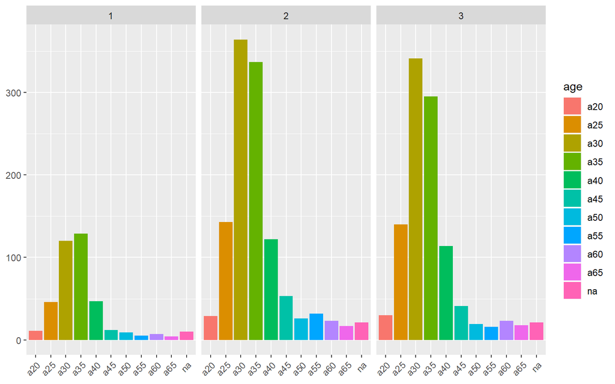

```r
A <- cat4A[, -c(12:15)] %>%
  cbind(K$cluster) %>%
  as.data.frame()
colnames(A)[ncol(A)] <- 'Cluster'

ggplot(data = A) +
  geom_bar(aes(x = age, fill = age)) +
  facet_wrap( ~ Cluster) +
  theme(axis.text.x = element_text(angle = 45, hjust = 1, vjust = 1),
        axis.title = element_blank())
```

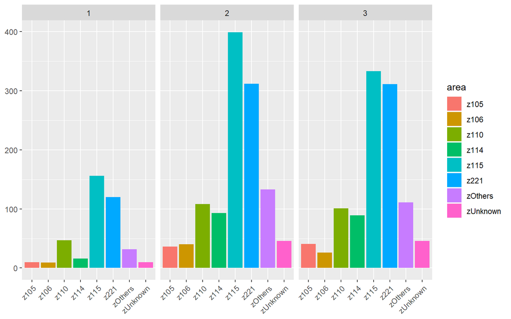

```r
ggplot(data = A) +
  geom_bar( aes( x = area, fill = area)) +
  facet_wrap( ~ Cluster) +
  theme(axis.text.x = element_text(angle = 45, hjust = 1, vjust = 1),
        axis.title = element_blank())
```

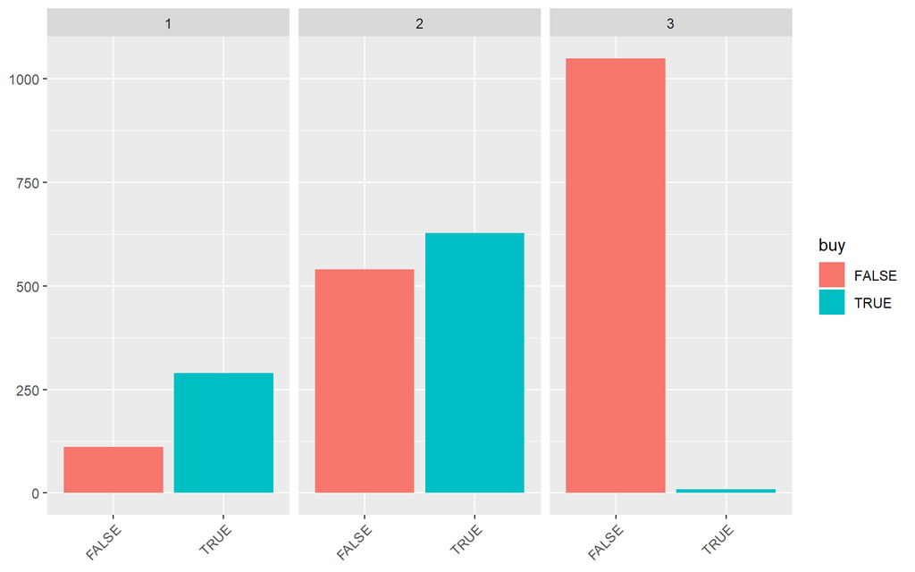

```r
ggplot(data = A) +
  geom_bar(aes(x = buy, fill = buy)) +
  facet_wrap( ~ Cluster) +
  theme(axis.text.x = element_text(angle = 45, hjust = 1, vjust = 1),
        axis.title = element_blank())
```

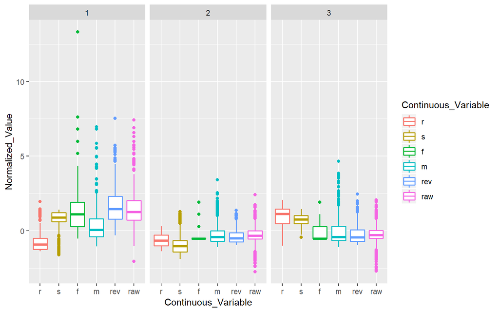

```r
A[,c(2:7, 10)] = scale(A[,c(2:7, 10)])

A$age = factor(A$age)
A$area = factor(A$area)
A$buy = factor(A$buy)
DummyTable <- model.matrix( ~ age + area + buy, data = A)
A <- cbind(
  A[, -c(1, 8, 9, 11,13:15)],
  DummyTable[, -1]
)
A$amount[is.na(A$amount)] = 0

ClusterResultForPlot <- A %>%
  gather( key = Continuous_Variable,
          value = Normalized_Value,
          - c(amount, agea25, agea30, agea35, agea40, agea45,
              agea50, agea55, agea60, agea65, agena,
              areaz106, areaz110, areaz114, areaz115, areaz221,
              areazOthers, areazUnknown, buyTRUE,Cluster))

ClusterResultForPlot$Continuous_Variable <- ClusterResultForPlot$Continuous_Variable %>% factor( levels = c('r', 's', 'f', 'm', 'rev', 'raw'))

ggplot( data = ClusterResultForPlot) +
  geom_boxplot( aes( x = Continuous_Variable,
                     y = Normalized_Value,
                    color = Continuous_Variable),
                size = 0.7) +
  facet_wrap( ~ Cluster)
```

保暖衣物分群：

- 群一【活躍老顧客】  
  會購買比率最高，30-40歲。他的S比較高，代表第一次購買是比較以前的事；r比較低表示有一些活躍的顧客，到最近都一直有在買，f很高代表購買次數也高，所以這些都是活躍老顧客。這三群的平均購買金額都在差不多的地方，所以這個商品比較那些顧客的應該是數量，數量買的比其他族群多，所以營收跟利潤也比其他族群多。分布位子比較不同的是信義區的客人突出。
- 群二【新加入顧客】（佔多數）  
  第一次購買是比較近期的事，推估因為是近期才加入的顧客，所以最近購買時間也差不多在近期。次數也比較少，但花的錢跟其他群差不多。獲利跟第三群差不多，推估第二群隨著時間會轉變成第一群或第三群。（買跟不買剛好平分秋色）。
- 群三【沈睡老顧客】  
  加入時間跟最近購買都在比較久以前，次數也沒有比較多，購買金額跟大家差不多，推測是買了一次就不想買的顧客。覺得可以不用挽回。

## 3.4 衛生紙kmeans分群與命名

### 3.4.1 資料前處理

### 3.4.2 分群：

```r
set.seed(500)
K <- kmeans(AA, 3)
ClusterResult <- cbind(
  AA,
  K$cluster
) %>% as.data.frame()
colnames(ClusterResult)[ncol(ClusterResult)] <- 'Cluster'
table(ClusterResult$Cluster)
```

```
##
##    1    2    3
## 2383 2024  741
```

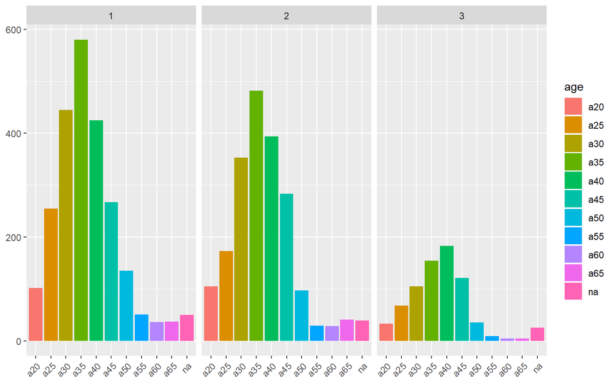

```r
A <- cat6A[, -c(12:15)] %>%
  cbind(K$cluster) %>%
  as.data.frame()
colnames(A)[ncol(A)] <- 'Cluster'

ggplot(data = A) +
  geom_bar(aes(x = age, fill = age)) +
  facet_wrap( ~ Cluster) +
  theme(axis.text.x = element_text(angle = 45, hjust = 1, vjust = 1),
        axis.title = element_blank())
```

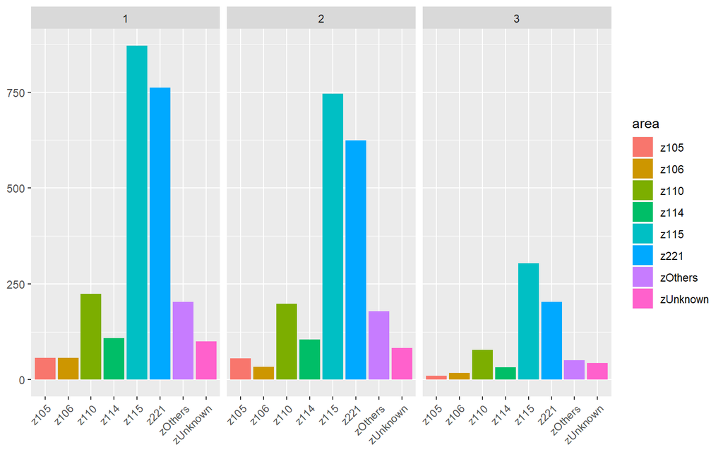

```r
ggplot(data = A) +
  geom_bar( aes( x = area, fill = area)) +
  facet_wrap( ~ Cluster) +
  theme(axis.text.x = element_text(angle = 45, hjust = 1, vjust = 1),
        axis.title = element_blank())
```

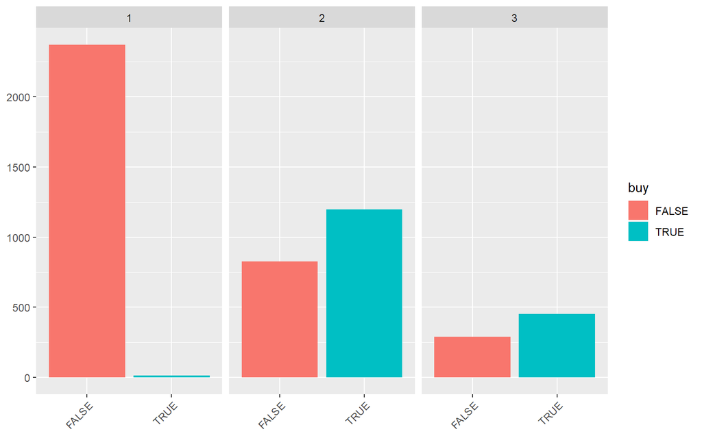

```r
ggplot(data = A) +
  geom_bar(aes(x = buy, fill = buy)) +
  facet_wrap( ~ Cluster) +
  theme(axis.text.x = element_text(angle = 45, hjust = 1, vjust = 1),
        axis.title = element_blank())
```

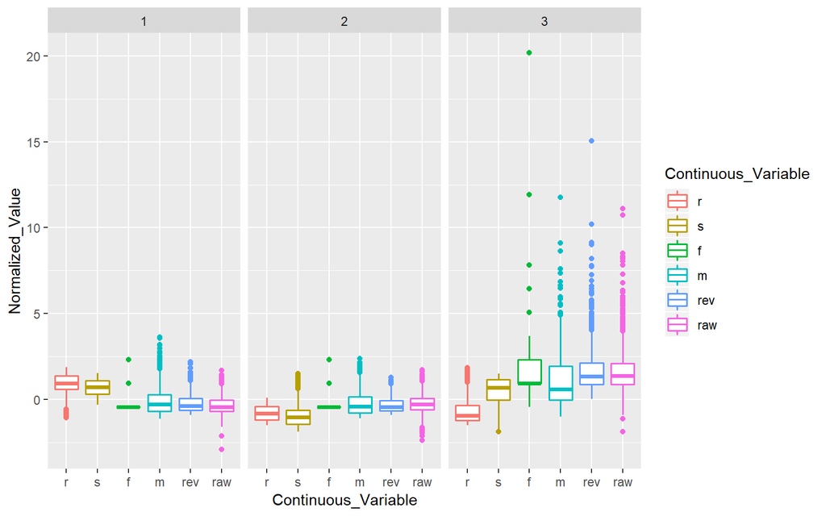

```r
A[,c(2:7, 10)] = scale(A[,c(2:7, 10)])

A$age = factor(A$age)
A$area = factor(A$area)
A$buy = factor(A$buy)
DummyTable <- model.matrix( ~ age + area + buy, data = A)
A <- cbind(
  A[, -c(1, 8, 9, 11,13:15)],
  DummyTable[, -1]
)
A$amount[is.na(A$amount)] = 0

ClusterResultForPlot <- A %>%
  gather( key = Continuous_Variable,
          value = Normalized_Value,
          - c(amount, agea25, agea30, agea35, agea40, agea45,
              agea50, agea55, agea60, agea65, agena,
              areaz106, areaz110, areaz114, areaz115, areaz221,
              areazOthers, areazUnknown, buyTRUE,Cluster))

ClusterResultForPlot$Continuous_Variable <- ClusterResultForPlot$Continuous_Variable %>% factor( levels = c('r', 's', 'f', 'm', 'rev', 'raw'))

ggplot( data = ClusterResultForPlot) +
  geom_boxplot( aes( x = Continuous_Variable,
                     y = Normalized_Value,
                    color = Continuous_Variable),
                size = 0.7) +
  facet_wrap( ~ Cluster)
```

# 肆、行銷策略發想

我們以整體顧客中的主力客戶為主，篩選出各品類中的一群，來縮小範圍，發想高效率行銷策略。以下內容皆為各品類某目標客群之特色、行銷方案剖析。

## 4.1 家電選擇行銷對象－群1衝動性購物群

### 4.1.1 分析原因：

從rsfm來看，這群非主要營收貢獻來源，但基數卻很大，r、s也偏低，代表是實際上近期有在購物的族群，地區分布上主要以南港汐止為主。

### 4.1.2 顧客價值與參數假設：

g為稅前獲利率、N為基數、d為利率。

- g = 0.5
- N = 4
- d = 0. 075

### 4.1.3 行銷策略：

針對此類客戶群，其較其他族群差異在於年輕與老人顧客比例較高，回購比率也較高，因此推斷其為行銷策略接受度與推廣其成為主力客戶較有機會的一群，因此可以利用推出限量商品、限時優惠，利用飢餓行銷的心理製造出顧客的危機感。

### 4.1.4 行銷工具規劃與方案：

限量商品限時折扣：從消費心理學的角度，衝動型消費顧客對於限時、季節限定商品有較高的敏感度，因此可以藉由此類廣告文宣推廣來出清家電存貨、過季商品等等。

針對家電類衝動型顧客做限量折扣、限時優惠的行銷方案如下：

- **新品每人限購2樣並贈送小禮品活動**：限購2樣本身沒成本，只有小禮物的成本但能達到限量購物的緊張感）
- **限時過季商品大清倉**：過季商品本身就較便宜，因此售價 = 成本 + 利潤加乘 （ 利潤加乘上可以拉高後再折抵）

### 4.1.5 成本估計：

限量禮品 25/人= 25 元

## 4.2 保暖衣物選擇行銷對象－群2新加入顧客

### 4.2.1 分析原因：

第2群跟第3群（沉睡老顧客）的地區、年齡分布很像，但他們大安區（傾向回購）的客人也比其他群多，再加上此群買與不買佔各半，人數又是最大群的，因此這群遊走的新顧客很適合作為我們的行銷對象，希望用我們的行銷策略，讓此群邁向穩定型顧客（群1），並防範他變成沉睡顧客。

### 4.2.2 顧客價值與參數假設：

g為稅前獲利率、N為基數、d為利率。

- g = 0.6
- N = 4
- d = 0. 075

### 4.2.3 行銷策略：

由於希望把第二群新加入客戶群導向忠誠老顧客，因此希望壓低r並提高f、m、rev、raw，因此我們可以藉由售後服務(例如免費修改)策略、新型促銷方案：利用購買即贈送下次才可使用之折價券；來提高回購率與整體銷量、來電送小贈品(如氣球)，並搭配給予銷售人員折扣配額並藉由銷售人員辨別出此群客戶後給予優惠，以提升此群客戶的回購率與品牌忠誠度。

### 4.2.4 行銷工具規劃與方案：

針對冬季衣物類新生顧客做的行銷方案如下：

- **售後服務**：在銷售後30分鐘發送購買衣物清洗建議與感謝簡訊，讓消費者感受到店家對其的重視，以提升消費者對於店家的好感度，增加其回購率。
- **廣告文宣**：利用廣告文宣頭提升觸及率與前述行銷方案之曝光度，也可以藉由有趣的廣播slogan即時提醒顧客有優惠活動，引起消費者注意。
- **來店小贈品**：在店門口發放氣球可以吸引家庭中有小孩的父母在購物時提高購物情趣，吸引小朋友目光，增加家庭購物氣氛提升消費者忠誠度，進而增加f、m、rev、raw。

### 4.2.5 成本估計：

簡訊3/人+廣告文宣（扣除廣播）5/人+來店小禮15/人 =23/人

## 4.3 衛生紙選擇行銷對象－群3購買力較高的忠誠老顧客

### 4.3.1 分析原因：

群3的人雖然比較少，但他加入時間也比較久以前，但近期仍有在購買；再加上其購物次數、每次消費金額都比其他群高，代表其為忠誠的老顧客、且購買力高。但是衛生紙是利潤上較低的商品，所以若能將此群顧客導向觸及本商場其他高利潤商品，也能夠連帶提升這群顧客的價值。

### 4.3.2 顧客價值與參數假設：

g為稅前獲利率、N為基數、d為利率。

- g = 0.15
- N = 4
- d = 0. 075

### 4.3.3 行銷策略：

因為群顧客固著力已經相較其他兩群強，因此多做額外優惠對於此類顧客群敏感度不夠大，本小組決定採用搭售的方式，藉由衛生紙搭售其他商品(如垃圾袋、尿布、濕紙巾、衛生用品)，搭配廣告優惠，將衛生紙放在月商品型錄中首頁或較顯眼處，即使折數不高，但因為是家家必備商品，一旦有優惠就會吸引老顧客多帶幾串回家，達到省錢小確幸，另外可搭配口碑式行銷，維護老顧客價值，吸引新顧客，並加深這些顧客與本公司的連結。

### 4.3.4行銷工具規劃與方案：

針對衛生紙類忠誠老顧客做的行銷方案如下：

- **搭售商品文宣**：在文宣中強調衛生紙可搭售其他商品，透過衛生紙忠誠顧客連帶提升其他品類的銷售量，並且提高該顧客的單次消費金額。
- **月型錄**：在月型錄中較顯眼之處，放入衛生紙折價廣告，藉以抓住新顧客的目光，透過價格優惠吸引需求彈性高的顧客購買商品，同時提升老顧客的單次消費金額。
- **口碑式行銷**：邀請老顧客成為重要會員，並提供之福利，如該顧客的親朋好友只要以此老顧客介紹之名來買，就可以有折價；而該老顧客只要邀請滿ｎ人，其購買衛生紙也會有折扣。一來維護老顧客，免於流失；二來能夠增加新顧客，並且是較為緊密的新顧客（有朋友的口碑，更願意留下）；三來，此舊顧客購買衛生紙的數量也會因優惠而提升。

### 4.3.5 成本估計：

搭售文宣、月型錄 10/人+ 搭售折扣 5/人 + 口碑式行銷(邀請顧客成為會員的簡訊、DM) 5/人 = 20/人

# 伍、模型與成本效益預測

首先，我們將各品類分群中的其中一群客戶，搭配整體分群中主力客戶編上號碼，取得交集之後，我們能夠更縮小客戶範圍，並以更主打的方式向重要客群行銷。  
再者，我們透過模型及預估，可以知道該用什麼樣的行銷方案、該對哪一群受眾實行、才是最有效率及效果的。

## 5.1 成本效益分析模擬：

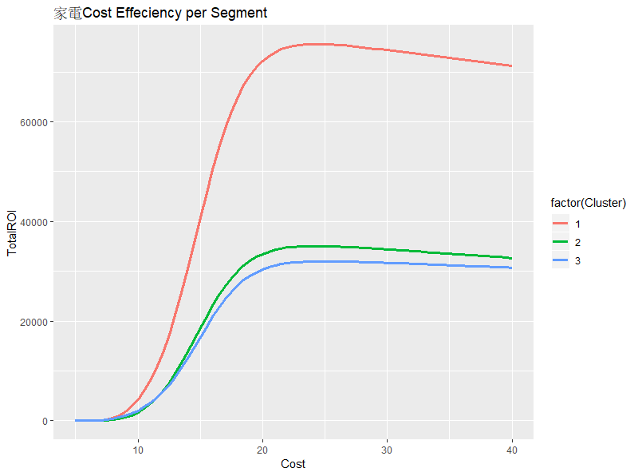

家電成本效益分析

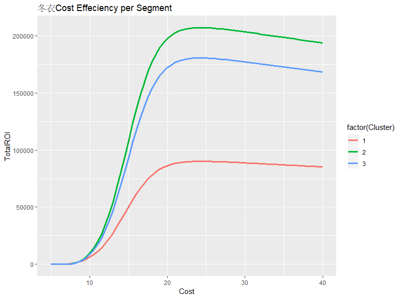

冬天保暖衣物成本效益分析

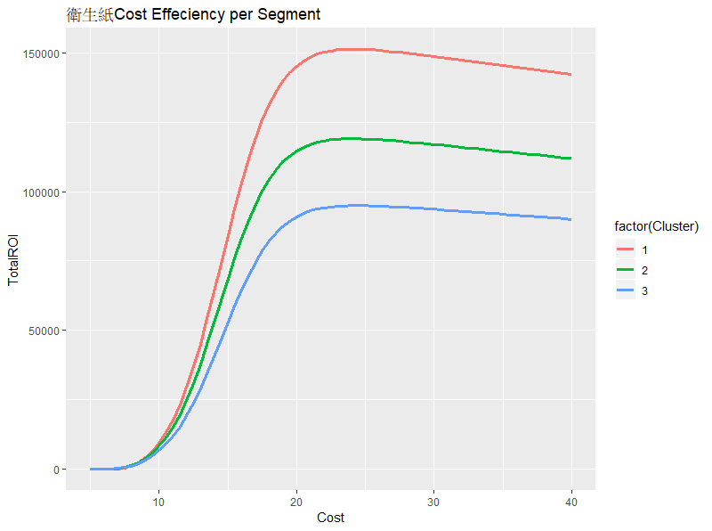

衛生紙成本效益分析

```r
# library(manipulate)
# library(latex2exp)
# MRG = 0.3
#
# manipulate({
#   do.call(rbind, lapply(seq(5, 40, 0.5), function(c){
#     p = m * plogis((10 / a)*(c - b))
#     # CData %>% mutate(
#     app %>% mutate(
#     # cloth %>% mutate(
#     # napkin %>% mutate(
#       PI = ifelse(pred <= (1 - p), p, 1 - pred) * Rev - c
#     ) %>%
#       group_by(Cluster) %>% summarise(
#         Cost = c,
#         Group.Sz = n(),
#         No.Target = sum(PI > 0),
#         AvgROI = mean(PI[PI > 0]),
#         TotalROI = sum(PI[PI > 0])
#       ) } ) ) %>%
#     ggplot(aes(x = Cost, y = TotalROI, col = factor(Cluster))) +
#     geom_line(size = 1.2) +
#     ggtitle("Cost Effeciency per Segment ")
# },
# m = slider(0.05, 0.25,  0.20, step = 0.01),
# a = slider(10, 30, 20, step = 1),
# b = slider(4, 20, 15, step = 1)
# )
```

## 5.2 方案一：家電類衝動行銷

#### 顧客終身價值、預期效益：

預期購買機率0.62  
預期利潤 1712  
顧客價值 2324  
ROI約 54708.55

```r
# app　為已選定的 TA 群（為家電衝動客戶群與整體主力客戶的交集）
Target = app

g = 0.5
N = 4
d = 0.075
Target$CLV = g * Target$Rev * rowSums(sapply(
  0:N, function(i) (Target$pred/(1 + d))^i ) )

summary(Target$CLV)
```

```
##    Min. 1st Qu.  Median    Mean 3rd Qu.    Max.
##   191.4  1097.0  1586.3  2637.4  2623.6 91001.3
```

```r
sapply(Target[, 13:15], tapply, Target$Cluster, mean)
```

```
##        pred      Rev      CLV
## 1 0.6190244 1712.044 2324.006
## 2 0.5949236 1624.741 2305.352
## 3 0.6651279 2645.241 4075.932
```

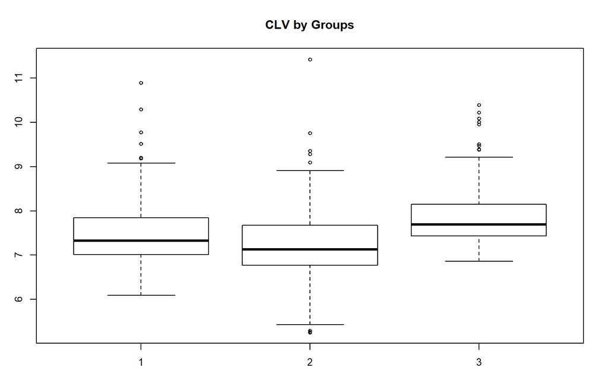

```r
par(mar = c(3, 3, 4, 2), cex = 0.8)
boxplot(log(CLV) ~ Cluster, Target, main = "CLV by Groups")
```

```r
cost = 25       # 成本
effect = 0.62    # 效益：下一期的購買機率

Target$ExpReturn = (effect - Target$pred) * Target$Rev - cost
summary(Target$ExpReturn)
```

```
##      Min.   1st Qu.    Median      Mean   3rd Qu.      Max.
## -15926.54   -347.33    -24.19   -162.24    241.27   1434.91
```

```r
Target %>% arrange(desc(ExpReturn)) %>% dplyr::select(cust, ExpReturn) %>% head(15)
```

```
##        cust ExpReturn
## 1  00633536 1434.9090
## 2  01446876 1206.7591
## 3  01958706 1156.5320
## 4  01748918 1088.8331
## 5  01694178 1063.4915
## 6  00312844 1053.4883
## 7  01316421 1018.9968
## 8  01635195  999.0253
## 9  00726023  995.5821
## 10 01038262  985.8785
## 11 01828788  948.4243
## 12 01869293  938.3036
## 13 00437585  928.6875
## 14 00944106  903.6595
## 15 01144086  876.2612
```

```r
sum(Target$ExpReturn > 0, na.rm = T)                    # 可實施對象
```

```
## [1] 312
```

```r
sum(Target$ExpReturn[Target$ExpReturn > 0], na.rm = T)  # 預期報酬
```

```
## [1] 99988.91
```

```r
Target$ExpReturn = (effect - Target$pred) * Target$Rev - cost
filter(Target, Target$ExpReturn > 0) %>%
  group_by(Cluster) %>% summarise(
    No.Target = n(),
    AvgROI = mean(ExpReturn),
    TotalROI = sum(ExpReturn) ) %>% data.frame
```

```
##   Cluster No.Target   AvgROI TotalROI
## 1       1       168 325.6461 54708.55
## 2       2        96 257.5553 24725.31
## 3       3        48 428.2302 20555.05
```

## 5.3 方案二：保暖衣物類忠誠度提高行銷

#### 顧客終身價值、預期效益：

預期購買機率0.59  
預期利潤 1438  
顧客價值 2172  
ROI約 127267.2

```r
# cloth　為已選定的 TA 群（為保暖衣物新生客戶群與整體主力客戶的交集）
Target = cloth

g = 0.6
N = 4
d = 0.075
Target$CLV = g * Target$Rev * rowSums(sapply(
  0:N, function(i) (Target$pred/(1 + d))^i ) )

summary(Target$CLV)
```

```
##      Min.   1st Qu.    Median      Mean   3rd Qu.      Max.
##     83.68   1136.17   1662.54   2461.47   2543.91 109201.58
```

```r
sapply(Target[, 13:15], tapply, Target$Cluster, mean)
```

```
##        pred      Rev      CLV
## 1 0.7242912 2336.802 4513.925
## 2 0.5891474 1437.909 2171.933
## 3 0.5505467 1353.264 1929.861
```

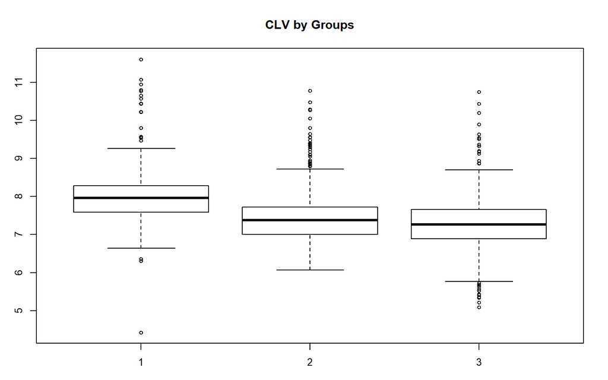

```r
par(mar = c(3, 3, 4, 2), cex = 0.8)
boxplot(log(CLV) ~ Cluster, Target, main = "CLV by Groups")
```

```r
cost = 23       # 成本
effect = 0.59    # 效益：下一期的購買機率

Target$ExpReturn = (effect - Target$pred) * Target$Rev - cost
summary(Target$ExpReturn)
```

```
##      Min.   1st Qu.    Median      Mean   3rd Qu.      Max.
## -17179.93   -286.64    -24.79   -121.45    206.20   1230.23
```

```r
Target %>% arrange(desc(ExpReturn)) %>% dplyr::select(cust, ExpReturn) %>% head(15)
```

```
##        cust ExpReturn
## 1  01811902 1230.2336
## 2  00839389 1195.6211
## 3  01873658 1137.4109
## 4  01637397 1105.5105
## 5  00406826 1048.0736
## 6  01664287 1040.7047
## 7  01637328  959.7816
## 8  01250152  905.5616
## 9  01811650  901.8453
## 10 01522853  899.4295
## 11 01739930  896.7170
## 12 01351507  861.9533
## 13 01622355  859.4664
## 14 02135069  857.0990
## 15 01844085  851.9643
```

```r
sum(Target$ExpReturn > 0, na.rm = T)                    # 可實施對象
```

```
## [1] 1113
```

```r
sum(Target$ExpReturn[Target$ExpReturn > 0], na.rm = T)  # 預期報酬
```

```
## [1] 291144.6
```

```r
Target$ExpReturn = (effect - Target$pred) * Target$Rev - cost
filter(Target, Target$ExpReturn > 0) %>%
  group_by(Cluster) %>% summarise(
    No.Target = n(),
    AvgROI = mean(ExpReturn),
    TotalROI = sum(ExpReturn) ) %>% data.frame
```

```
##   Cluster No.Target   AvgROI  TotalROI
## 1       1        96 280.7871  26955.56
## 2       2       509 250.0338 127267.19
## 3       3       508 269.5312 136921.86
```

## 5.4 方案三：衛生紙類忠誠顧客轉換行銷

#### 顧客終身價值、預期效益：

預期購買機率0.76  
預期利潤 2498.418  
顧客價值 1271.6908  
ROI約 77082.69

```r
#  napkin　為已選定的 TA 群（為衛生紙類忠誠顧客群與整體主力客戶的交集）
Target =  napkin

g = 0.15
N = 4
d = 0.075
Target$CLV = g * Target$Rev * rowSums(sapply(
  0:N, function(i) (Target$pred/(1 + d))^i ) )

summary(Target$CLV)
```

```
##     Min.  1st Qu.   Median     Mean  3rd Qu.     Max.
##    78.49   479.49   678.10   957.85   955.50 27300.40
```

```r
sapply(Target[, 13:15], tapply, Target$Cluster, mean)
```

```
##        pred      Rev       CLV
## 1 0.7082909 1741.074  773.1654
## 2 0.7687552 1981.453  956.0400
## 3 0.7615860 2498.418 1271.6908
```

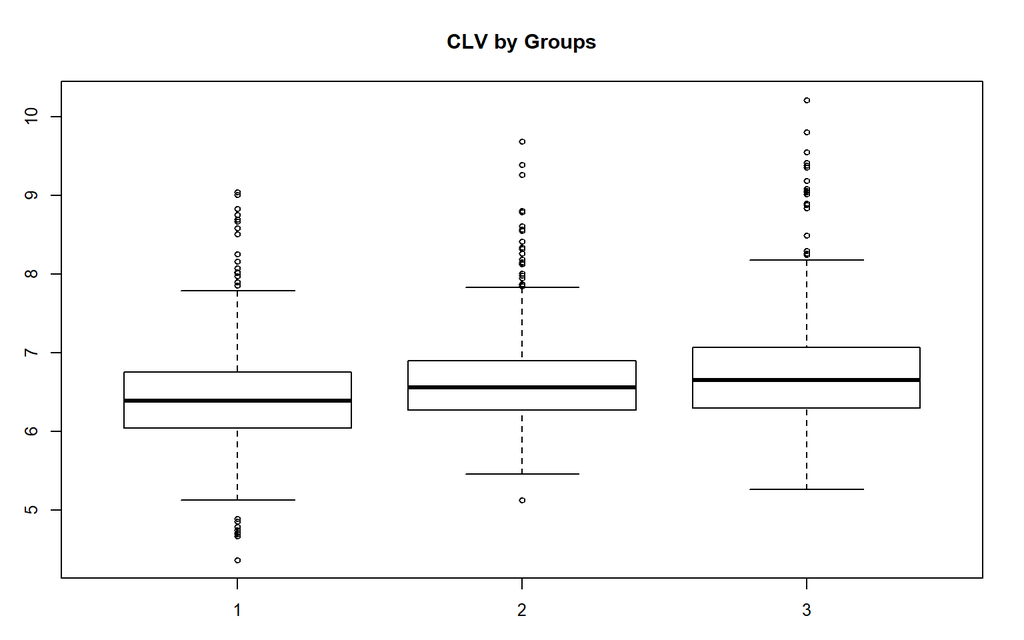

```r
par(mar = c(3, 3, 4, 2), cex = 0.8)
boxplot(log(CLV) ~ Cluster, Target, main = "CLV by Groups")
```

```r
cost = 20       # 成本
effect = 0.76    # 效益：下一期的購買機率

Target$ExpReturn = (effect - Target$pred) * Target$Rev - cost
summary(Target$ExpReturn)
```

```
##      Min.   1st Qu.    Median      Mean   3rd Qu.      Max.
## -10063.08   -294.53    -69.06    -54.02    233.59   2074.98
```

```r
Target %>% arrange(desc(ExpReturn)) %>% dplyr::select(cust, ExpReturn) %>% head(15)
```

```
##        cust ExpReturn
## 1  00959391  2074.980
## 2  01618549  1986.830
## 3  00633536  1923.889
## 4  02172941  1748.275
## 5  00441742  1742.001
## 6  01044560  1737.196
## 7  01811902  1724.839
## 8  00002189  1696.222
## 9  01815498  1650.111
## 10 01420296  1647.320
## 11 01701555  1612.417
## 12 01401110  1605.762
## 13 00896139  1584.184
## 14 02100432  1560.671
## 15 01664287  1551.437
```

```r
sum(Target$ExpReturn > 0, na.rm = T)                    # 可實施對象
```

```
## [1] 774
```

```r
sum(Target$ExpReturn[Target$ExpReturn > 0], na.rm = T)  # 預期報酬
```

```
## [1] 328140.5
```

```r
Target$ExpReturn = (effect - Target$pred) * Target$Rev - cost
filter(Target, Target$ExpReturn > 0) %>%
  group_by(Cluster) %>% summarise(
    No.Target = n(),
    AvgROI = mean(ExpReturn),
    TotalROI = sum(ExpReturn) ) %>% data.frame
```

```
##   Cluster No.Target   AvgROI  TotalROI
## 1       1       363 444.3325 161292.68
## 2       2       223 402.5343  89765.14
## 3       3       188 410.0143  77082.69
```

# 陸、總結

[output not shown]

- 首先根據顧客價值篩選行銷案，培養出較有價值的客戶群，就能做到店內顧客價值提升與永續。  
  估計會是**家電類的衝動型顧客群**（顧客價值2324）較適合將行銷資源做集中利用，再預估其購買機率為0.619、預期利潤1712.044，再預期其未來期望報酬(ROI) = 54708！
- 但若考量未來所帶來的預期報酬大小，顧客價值與電器類衝動型顧客相近的**冬季衣物新加入顧客群**會有更大的潛力，其預估購買機率為0.58914、預期利潤為1438，但未來期望報酬會高達127267！

R程式語言、機率統計與商業實務 Group15

2019年6月16日